# **긍정 & 부정 감성 분석이 언택트 기업 가치에 미치는 영향**

- 경제금융대학 박수규(2022233129)

# 1. Introduction

- 코로나 19로 인한 팬데믹 선언으로 인해 사회가 셧다운 되면서 비대면에 대한 관심도가 상승
- 그로 인한 언택트 관련 주식의 높은 누적 초과 수익률 발생
- 언택트 산업에 대한 긍정적인 뉴스가 나온 날의 누적 초과 수익률과 부정적인 뉴스가 나온 날의 누적 초과 수익률의 방향성 확인

1) 기존의 주식에 관련한 정형 데이터에 비정형 텍스트 데이터를 변수로 추가하여 언택트 버블의 신호를 더 명확하게 하는 것에 목적이 있음  
2) 본 보고서에서는 언택트 데이터를 다 분석하지 못하고 카카오 주식만 가지고 분석하였음

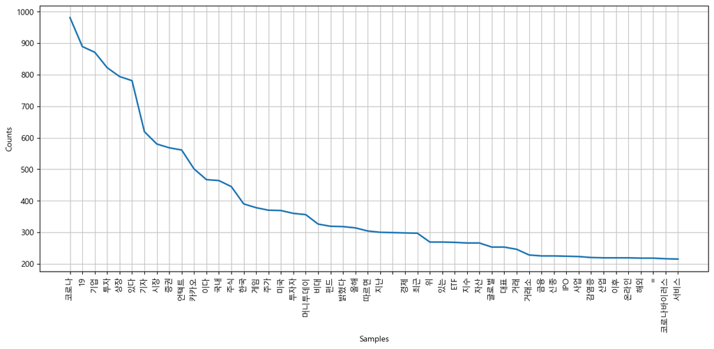

- 단어별 뉴스에 언급된 횟수는 상장 주식 중에는 카카오가 가장 높아서 카카오를 통해서 분석을 시행하고자 함
- 보고서의 구성은 Introdution, Literature Review, Research methodology, Data, Empirical Results, Conclusion

# 2. Literature Review

## 2.1 팬데믹 선언의 기업 가치 효과

- 팬데믹 선언과 관련된 국내외 선행연구((조용복 외, 2020; Liu et al., 2020; Chowdhury etal., 2020) 팬데믹 선언에 따른 특정 국가의 주식 시장, 특정 산업군에 대한 기업 가치 변화를 중심으로 연구되어 옴
- 산업군에 대한 구분 없이 국내외 주가 시장 전반에 대한 변화 분석(Liu et al., 2020; Chowdhury et al., 2020), 수혜 산업으로 보기 어려운 산업군에 대한 분석(조용복 외, 2020)

## 2.2 언택트 산업의 기업 가치 효과

- 사람과 사람간의 접촉을 디지털화한 산업으로 비즈니스의 무인화를 가능하게 하는 산업(최승훈, 2020)
- 펜데믹 선언과 직접적인 관련 산업으로 언택트 산업을 지목
- 팬데믹 선언의 결과로 사람들은 언택트 산업에 큰 관심을 갖기 시작하였고 트렌드가 됨

## 2.3 투자자 마니아 가설과 언택트 산업의 기업 가치 효과

- 잠재력을 가진 새로운 산업에 열광하는 투자자들이 그 산업과 관련된 기업에 투자한다는 가설(Cooper et al., 2001; 박정미 외, 2019)
- 기업 사명 변경(Feng et al., 2021; Lin et al, 2016; 박정미 외, 2019)을 위주로 특정 시장, 산업군, 혹은 시장의 버블 존재 여부 분석

## 2.4 뉴스 보도에 따른 감성 분석

- 팬데믹으로 인해 빅데이터와 인공지능의 발달로 재무 정보 뿐만아니라 뉴스 기사나 소셜미디어 정보와 같은 텍스트 데이터 연구 활발(송한솔 외, 2022)

# 3. Research methodology

- 투자자 마니아 가설 검증을 위한 보편적 방법론인 이벤트 스터디 사용
- 시장 수익률 모형 사용
- 뉴스에 속한 단어의 감성이 긍정인지 혹은 부정인지에 따라 감성 점수를 부여하고 점수가 클수록 긍정 작을수록 부정

## 3-1-1. 언택트 산업 연구 모형

- 주식 분할 공시의 정보 효과를 분석하면서 효율적 시장 가설을 증명하기 위한 방법론으로 제시 한 이론
- 기업의 고유한 특정 사건에 대한 주가 반응 연구에 활용

## 3-1-2. 이벤트 스터디

- 시장수익률 모형을 통해 시장 수익률과 주가 수익률을 회귀하여 구함  
  ### $R_i,t$=$\alpha$ +$\beta$ *$R_m,t$+$\epsilon_i,t$

## 3-1-3. 감성 분류 - 로지스틱 회귀

- 언택트 기업이 뉴스에 많이 등장하고, 그 내용이 긍정적이면 높은 점수를 부여
- 주식시장이 강한 상승장세이면 높은 점수 부여
- 반대의 경우 반대
- BERT모형 중 금융 도메인을 위한 FinBERT 모형은 말뭉치에 사전적 추가 교육이 수행되는 방식을 말함

[figure not shown]

# 4. Data

- 금융 도메인에 특화된 주제이기 때문에 뉴스 데이터 사용
- 뉴스의 감성을 긍정과 부정 두 가지로 분류
- 긍정과 부정의 점수가 나오면 그 점수를 토대로 평가를 5단계로 나눔
- 한국어 자연어 처리와 금융 도메인 자연어 처리 방법인 **KR_FinBERT**를 이용하여 감성 점수 구함
- 뉴스 데이터는 빅카인즈 검색 포털 활용 : **키워드(언택트), 데이터 기간(2020.03.11 ~ 2022.11.30), 총 1880건의 기사**를 활용하여 보고서 작성

[figure not shown]

```
import re
from tqdm import tnrange, tqdm_notebook, tqdm

for i,s in enumerate(tqdm(news_df['본문'])):
    text = news_df.loc[i, '본문']
    text = text.replace("'","")
    text = text.replace("#", "")
    text = text.replace('\n',"")
    text = text.replace('[',"")
    text = text.replace(']',"")
    text = text.replace('""',"")
    text = text.replace('&',"")
    text = text.replace('/',"")
    text = text.replace('.'," ")
    text = text.replace('무단 전재 및 재배포 금지',"")
    text = text.replace('무단전재 및 재배포 금지',"")
    text = text.replace('무단 전재-재배포 금지',"")
    text = re.sub(r'[%$^*,~()=★@※♥°●↑"\t▶ⓒ<>-△▽]','',text)
    text = re.sub('https?://(?:[-\w.]|(?:%[\da-fA-F]{2}))+', '', text, flags=re.MULTILINE)
    text = re.sub('@\\w+ *', '', text, flags=re.MULTILINE)
    news_df.loc[i, '본문'] = text
```

- 불용어 처리 코드